# Define Custom Response Distributions with brms

Paul Bürkner, Hayden Rabel

2022-03-17

## Introduction

The **brms** package comes with a lot of built-in response distributions – usually called *families* in R – to specify among others linear, count data, survival, response times, or ordinal models (see `help(brmsfamily)` for an overview). Despite supporting over two dozen families, there is still a long list of distributions, which are not natively supported. The present vignette will explain how to specify such *custom families* in **brms**. By doing that, users can benefit from the modelling flexibility and post-processing options of **brms** even when using self-defined response distributions.

If you have built a custom family that you want to make available to other users, you can submit a pull request to this [GitHub repository](https://github.com/paul-buerkner/custom-brms-families).

## A Case Study

Suppose we are interested in predicting variability of ocean acidity around New Zealand, and how it might change during climate phases of [El Niño and La Niña](https://niwa.co.nz/climate/information-and-resources/elnino). First we can load the **brms** dataset `nzocean`, and note the following variables of interest:

- `pco2`: Ocean acidity, partial CO<sub>2</sub> in μatm.
- `phase`: El Niño Southern Oscillation phase.

```r
# load the data
data('nzocean')

# remove fluctuating phase to just look at stable enso periods
nzocean <- nzocean[nzocean$phase != 'Fluctuating', ]

# and drop missing pco2 rows (link to missing values vignette?)
nzocean <- nzocean[!is.na(nzocean$pco2), ]

# print
head(nzocean, n = 10)
```

```
          date temp    sal  pco2   dioc    pH   soi   phase
1   1998-01-20 10.5 34.268 348.8 2084.5 8.095 -2.34 El Niño
2   1998-02-16 12.9 34.294 351.8 2058.3 8.091 -1.73 El Niño
3   1998-03-17 12.0 34.255 340.8 2061.2 8.103 -2.77 El Niño
10  1998-10-05  8.6 34.324 366.1 2102.6 8.074  1.07 La Niña
11  1998-10-21  9.2 34.297 363.4 2084.1 8.075  1.07 La Niña
12  1998-11-16 10.3 34.263 370.8 2086.1 8.070  1.14 La Niña
31  2000-06-01 10.3 34.300 369.6 2100.4 8.074 -0.46 Neutral
69  2003-08-12  7.7 34.238 360.5 2115.5 8.081 -0.14 Neutral
71  2003-10-15  8.8 34.408 364.1 2109.4 8.078 -0.18 Neutral
115 2007-04-02 11.6 34.285 354.4 2079.0 8.089 -0.14 Neutral
```

Now after some [histomancy](https://bookdown.org/content/4857/big-entropy-and-the-generalized-linear-model.html#rethinking-the-scourge-of-histomancy.) we might assume that observations of ocean acidity (`pco2`), $y \in \mathbb{R}^+$, are generated from some Log-normal distribution, with mean, $\mu \in \mathbb{R}$, and standard deviation, $\sigma\in \mathbb{R}^+$.

The Log-normal model included in **brms** and [Stan](https://mc-stan.org/docs/2_29/functions-reference/lognormal.html) uses the log-scale parameterisation with the probability distribution function:

$$P(y | \mu, \sigma) =
\frac{1}{\sqrt{2\pi}\sigma}
\frac{1}{y}
\exp\left[
-\frac{1}{2}\left(\frac{\ln y - \mu}{\sigma}\right)^2
\right].
\tag{1}$$

This effectively says, we suspect that the logarithm, $n$, of the random variable $y$, follows a normal distribution. I.e.,

$$\begin{aligned}
y &\sim \text{Lognormal}(\mu, \sigma)\\
&\implies\\
n = \ln y &\sim \text{Normal}(\mu_n, \sigma_n),\\
\end{aligned}
\tag{2}$$

where the parameters

$$\begin{aligned}
\mu_n &= \exp\left(\mu + \frac{\sigma^2}{2}\right),~\text{and}\\
\sigma_n &= \exp\left(\mu + \frac{\sigma^2}{2}\right)
\sqrt{\exp(\sigma ^ 2) - 1}
\end{aligned}
\tag{3}$$

are said to be on the *natural-scale* of $y$ (or `pco2`).

This model offers a bunch of nice properties, such as ensuring $y$ is strictly positive, and allowing response shapes from near-symmetric, small $\sigma$, to more right-skewed as $\sigma$ increases. Equations 2 & 3 also provide us a method to transform the parameters, $\mu$ and $\sigma$, back to the natural scale of `pco2`.

Now to predict `pco2`’s distribution using `phase`, we can try a simple model that assumes each phase corresponds to different posterior distributions of $\mu_y$ and $\sigma_y$, i.e., by varying intercepts,

$$\begin{aligned}
pco2_i &\sim \text{Lognormal}(\mu_i, \sigma_i) \\
\mu_i &= \alpha_{phase[i]} \\
\log \sigma_i &= \beta_{phase[i]}
\end{aligned}
\tag{4}$$

Note two things in this equation:

- The linear predictor for $\sigma$ is linked via the `log` function for strictly positive results and model efficiency (see `vignette("brms_overview")` for more details on links and linear predictors in **brms**).
- The priors for $\alpha_j$ and $\beta_j$ have not been specified – we will use the default **brms** flat priors for these intercept parameters as the main focus is on the Log-normal distribution family. For a proper analysis, one might want to centre and scale `pco2` then define some [slightly more informative priors](https://github.com/stan-dev/stan/wiki/Prior-Choice-Recommendations).

In **brms** this model is coded as:

```r
fit_ln <-
  brm(bf(pco2 ~ 0 + phase, sigma ~ 0 + phase),
      data = nzocean,
      seed = 0,
      family = lognormal(link = 'identity', link_sigma = 'log'))
```

In the summary output, we see that the population level estimates for each $\mu$ and $\sigma$ are much lower than the observed sample mean of 368 $\mu\text{atm}$, and standard deviation of 14, respectively. This is due to $\mu$ and $\sigma$ being on the log-scale in `brms::lognormal`, and the negative $\sigma$ values indicate these values are for it’s log-linked linear predictor. To get these on the same scale as `pco2`, we would need to first inverse the $\sigma$ estimates with `exp` then apply the transformations in equation 3 above.

```r
summary(fit_ln)
```

```
 Family: lognormal
  Links: mu = identity; sigma = log
Formula: pco2 ~ 0 + phase
         sigma ~ 0 + phase
   Data: nzocean (Number of observations: 30)
  Draws: 4 chains, each with iter = 2000; warmup = 1000; thin = 1;
         total post-warmup draws = 4000

Population-Level Effects:
                   Estimate Est.Error l-95% CI u-95% CI Rhat Bulk_ESS Tail_ESS
phaseNeutral           5.92      0.01     5.90     5.95 1.00     5044     2621
phaseLaNiña            5.89      0.01     5.87     5.91 1.00     4389     2869
phaseElNiño            5.89      0.03     5.84     5.94 1.00     3275     2104
sigma_phaseNeutral    -3.34      0.21    -3.72    -2.89 1.00     4100     2684
sigma_phaseLaNiña     -3.43      0.22    -3.82    -2.97 1.00     4401     2642
sigma_phaseElNiño     -2.91      0.35    -3.50    -2.12 1.00     3224     2067

Draws were sampled using sampling(NUTS). For each parameter, Bulk_ESS
and Tail_ESS are effective sample size measures, and Rhat is the potential
scale reduction factor on split chains (at convergence, Rhat = 1).
```

While applying these transformations for simple estimates may seem okay at first, when it comes to measures of uncertainty and any posterior summaries it may mean having to re-write or add a lot of messy code. For instance, plotting the posterior densities of each $\sigma_{phase}$ estimate is usually as concise as:

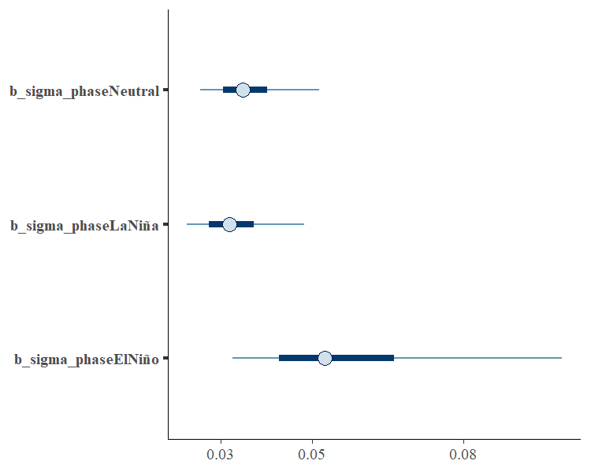

```r
mcmc_plot(fit_ln, variable = 'sigma', regex = TRUE) +
  # invert the log-link function
  scale_x_continuous(trans = 'exp', labels = function(l) round(exp(l), 2))
```

but to get this on the same scale as `pco2` we would need to reproduce the code for `mcmc_plot` and insert our transformations since posterior draws for each $\sigma_{phase}$ on the natural-scale are dependent on their associated $\mu_{phase}$ (equation 3).

## Reparameterising the Log-normal

To make potentially more intuitive inferences on the mean and variance of `pco2` without too much code, we could reparameterise the Log-normal distribution to use the natural-scale parameters $\mu_n$ and $\sigma_n$ directly. This yields the same formula as in equation 1,

$$P(y | \mu_n, \sigma_n) =
\frac{1}{\sqrt{2\pi}\sigma}
\frac{1}{y}
\exp\left[
-\frac{1}{2}\left(\frac{\ln y - \mu}{\sigma}\right)^2
\right],
\tag{5}$$

except now $\mu$ and $\sigma$ are expressed in terms of $\mu_n$ and $\sigma_n$ by reversing equation 3:

$$\begin{aligned}
\mu &= \ln\left(\frac{\mu_n}{\sqrt{1 + \sigma_n^2/\mu^2_n}}\right),\\
\sigma &= \sqrt{\ln\left(1 + \frac{\sigma_n^2}{\mu^2_n}\right)}.\\
\end{aligned}
\tag{6}$$

Let’s call this reparameterisation **lognormal7**, which now has the nice properties:

$$\text{E}(y) = \mu_n, \text{Var}(y) = \sigma_n^2.
\tag{7}$$

## Fitting Custom Family Models

The lognormal7 distribution is not natively supported in **brms** and so we will have to define it ourselves using the `custom_family` function. This function requires the family’s name, the names of its parameters (`mu` and `sigma` in our case), corresponding link functions (only applied if parameters are predicted), their theoretical lower and upper bounds (only applied if parameters are not predicted), information on whether the distribution is discrete or continuous, and finally, whether additional non-parameter variables need to be passed to the distribution. For our lognormal7 example, this results in the following custom family:

```r
lognormal7 <-
  custom_family(name = 'lognormal7',
                dpars = c('mu', 'sigma'),
                # log links to prevent underflow
                links = c('log', 'log'),
                lb = c(0, 0),
                type = 'real')
```

Next, we have to provide the relevant **Stan** functions if the distribution is not defined in **Stan** itself. For the `lognormal7` distribution, this is straight forward since the log-scale `lognormal` distribution is already implemented [here](https://mc-stan.org/docs/2_29/functions-reference/lognormal.html).

```r
stan_funs <- paste0('
  // see transformations in equation (6):
  real mu_ln(real mu_n, real sigma_n) {
    return log(mu_n / sqrt(1 + sigma_n ^ 2 / mu_n ^ 2));
  }
  real sigma_ln(real mu_n, real sigma_n) {
    return sqrt(log(1 + sigma_n ^ 2 / mu_n ^ 2));
  }
  // log-probability distribution
  real lognormal7_lpdf(real y, real mu_n, real sigma_n) {
    return lognormal_lpdf(y | mu_ln(mu_n, sigma_n), sigma_ln(mu_n, sigma_n));
  }
  // random number generator
  real lognormal7_rng(real mu_n, real sigma_n) {
    return lognormal_rng(mu_ln(mu_n, sigma_n), sigma_ln(mu_n, sigma_n));
  }
')
```

For the model fitting, we will only need `lognormal7_lpdf`, but `lognormal7_rng` will come in handy when it comes to post-processing (we could use `stats::rlnorm` but using the Stan random number generator will be more generalisable for other distributions not built in to R).

The code for these functions is added to the correct block of **Stan** code by:

```r
stanvars <- stanvar(scode = stan_funs, block = "functions")
```

Then we have all components together to fit our custom `lognormal7` model:

```r
fit_ln7 <-
  brm(bf(pco2 ~ 0 + phase, sigma ~ 0 + phase),
      data = nzocean,
      seed = 0,
      family = lognormal7,
      stanvars = stanvars)
```

The estimates in the summary output are still on a log-scale, except that this time only the `exp` inverse link function is required:

```r
summary(fit_ln7)
```

```
 Family: lognormal7
  Links: mu = log; sigma = log
Formula: pco2 ~ 0 + phase
         sigma ~ 0 + phase
   Data: nzocean (Number of observations: 30)
  Draws: 4 chains, each with iter = 2000; warmup = 1000; thin = 1;
         total post-warmup draws = 4000

Population-Level Effects:
                   Estimate Est.Error l-95% CI u-95% CI Rhat Bulk_ESS Tail_ESS
phaseNeutral           5.93      0.01     5.91     5.95 1.00     4241     2532
phaseLaNiña            5.90      0.01     5.88     5.92 1.00     4467     2822
phaseElNiño            5.90      0.03     5.84     5.95 1.00     2656     1944
sigma_phaseNeutral     2.59      0.22     2.20     3.06 1.00     4305     2514
sigma_phaseLaNiña      2.47      0.23     2.07     2.95 1.00     3842     2774
sigma_phaseElNiño      2.98      0.35     2.42     3.78 1.00     2955     2361

Draws were sampled using sampling(NUTS). For each parameter, Bulk_ESS
and Tail_ESS are effective sample size measures, and Rhat is the potential
scale reduction factor on split chains (at convergence, Rhat = 1).
```

Now we can visualise uncertainties now in terms of `pco2` standard deviations for each El Niño phase via the same code as before

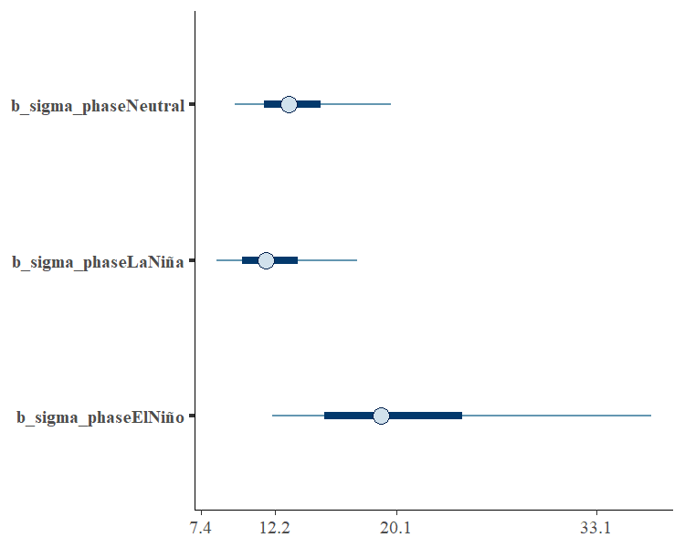

```r
mcmc_plot(fit_ln7, variable = 'sigma', regex = TRUE) +
  # invert the log-link function
  scale_x_continuous(trans = 'exp', labels = function(l) round(exp(l), 1))
```

## Post-Processing Custom Family Models

Some post-processing methods such as `summary` or `mcmc_plot` work out of the box for custom family models. However, there are three particularly important methods, which require additional input by the user. These are `posterior_epred`, `posterior_predict` and `log_lik` computing predicted mean values, predicted response values, and log-likelihood values, respectively. They are not only relevant for their own sake, but also provide the basis of many other post-processing methods. For instance, we may be interested in comparing the fit of the log-scale model with that of the natural-scale model by means of approximate leave-one-out cross-validation implemented in method `loo`, which in turn requires `log_lik` to be working.

The `log_lik` function of a family should be named `log_lik_<family-name>` and have the two arguments `i` (indicating observations) and `prep`. You don’t have to worry too much about how `prep` is created (if you are interested, check out the `prepare_predictions` function). Instead, all you need to know is that parameters are stored in slot `dpars` and data are stored in slot `data`. Generally, parameters take on the form of a $S \times N$ matrix (with $S =$ number of posterior draws and $N =$ number of observations) if they are predicted (as in our example) and a vector of size $N$ if the are not predicted.

We could define the complete log-likelihood function in R directly, or we can expose the self-defined **Stan** functions and apply them. The latter approach is usually more convenient, but the former is more stable and the only option when implementing custom families in other R packages building upon **brms**. For the purpose of the present vignette, we will go with the latter approach.

```r
expose_functions(fit_ln7, vectorize = TRUE)
```

Then define the required `log_lik` function with a few lines of code.

```r
log_lik_lognormal7 <- function(i, prep) {
  mu <- prep$dpars$mu[, i]
  sigma <- prep$dpars$sigma[, i]
  y <- prep$data$Y[i]
  lognormal7_lpdf(y, mu, sigma)
}
```

With that being done, all of the post-processing methods requiring `log_lik` will work as well. For instance, model comparison can simply be performed via

```r
loo(fit_ln, fit_ln7)
```

```
Output of model 'fit_ln':

Computed from 4000 by 30 log-likelihood matrix

         Estimate  SE
elpd_loo   -123.7 3.5
p_loo         4.5 0.9
looic       247.5 7.0
------
Monte Carlo SE of elpd_loo is 0.1.

Pareto k diagnostic values:
                         Count Pct.    Min. n_eff
(-Inf, 0.5]   (good)     29    96.7%   1249
 (0.5, 0.7]   (ok)        1     3.3%   376
   (0.7, 1]   (bad)       0     0.0%   <NA>
   (1, Inf)   (very bad)  0     0.0%   <NA>

All Pareto k estimates are ok (k < 0.7).
See help('pareto-k-diagnostic') for details.

Output of model 'fit_ln7':

Computed from 4000 by 30 log-likelihood matrix

         Estimate  SE
elpd_loo   -123.9 3.5
p_loo         4.6 1.0
looic       247.8 7.0
------
Monte Carlo SE of elpd_loo is 0.1.

Pareto k diagnostic values:
                         Count Pct.    Min. n_eff
(-Inf, 0.5]   (good)     28    93.3%   982
 (0.5, 0.7]   (ok)        2     6.7%   633
   (0.7, 1]   (bad)       0     0.0%   <NA>
   (1, Inf)   (very bad)  0     0.0%   <NA>

All Pareto k estimates are ok (k < 0.7).
See help('pareto-k-diagnostic') for details.

Model comparisons:
        elpd_diff se_diff
fit_ln   0.0       0.0
fit_ln7 -0.2       0.1
```

Since larger `ELPD` values indicate better fit, this would suggest that the log-scale lognormal model fits ever-so-slightly better. Though, given these two models are just different parameterisations of the same underlying distribution, this difference is likely just noise introduced by different sampling efficiencies.

Next, we will define the function necessary for the `posterior_predict` method:

```r
posterior_predict_lognormal7 <- function(i, prep, ...) {
  mu <- prep$dpars$mu[, i]
  sigma <- prep$dpars$sigma[, i]
  lognormal7_rng(mu, sigma)
}
```

The `posterior_predict` function looks pretty similar to the corresponding `log_lik` function, except that we are now creating random draws of the response instead of log-likelihood values. Again, we are using an exposed **Stan** function for convenience. Make sure to add a `...` argument to your `posterior_predict` function even if you are not using it, since some families require additional arguments. With `posterior_predict` to be working, we can engage for instance in posterior-predictive checking:

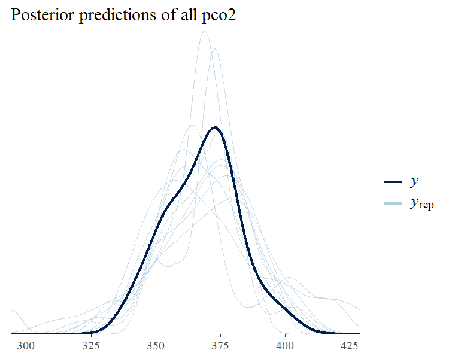

```r
pp_check(fit_ln7) +
  ggtitle('Posterior predictions of all pco2')
```

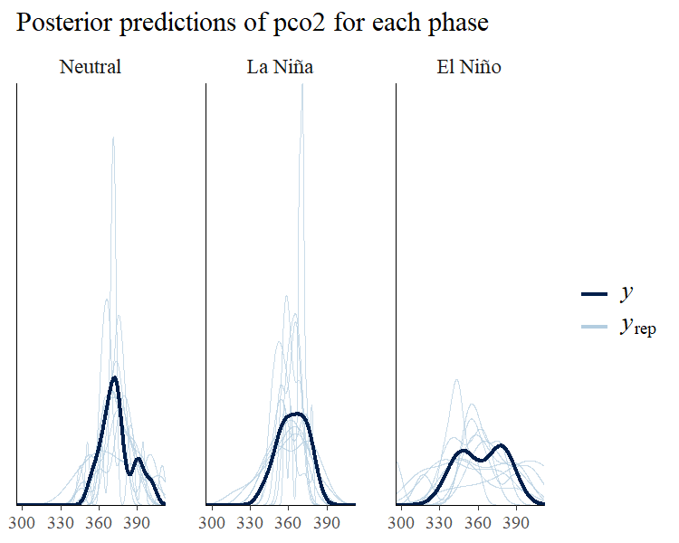

```r
pp_check(fit_ln7, type = 'dens_overlay_grouped', group = 'phase') +
  ggtitle('Posterior predictions of pco2 for each phase')
```

When defining the `posterior_epred` function, you have to keep in mind that it has only a `prep` argument and should compute the mean response values for all observations at once. Since the expected value of the `lognormal7` distribution on the natural scale is simply it’s mean (equation 7), the definition of the corresponding `posterior_epred` function is straightforward:

```r
posterior_epred_lognormal7 <- function(prep) {
  prep$dpars$mu
}
```

A post-processing method relying directly on `posterior_epred` is `conditional_effects`, which allows to visualize effects of predictors.

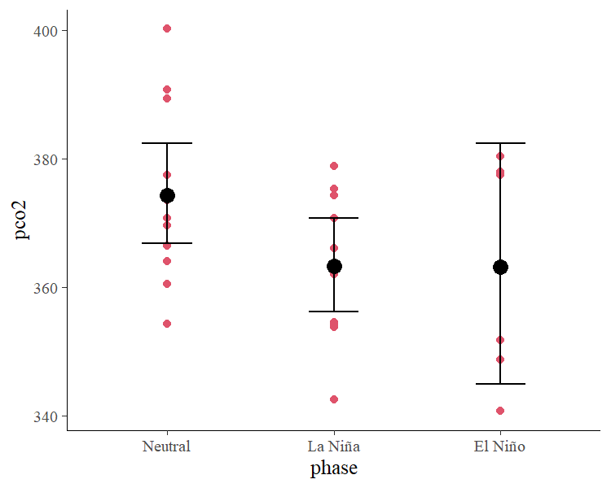

```r
plot(conditional_effects(fit_ln7),
     points = TRUE,
     point_args = list(col = 2))
```

The large black dots and error bars show the predicted mean and 95% density intervals, while the small red dots show the actual data points.

## Turning a Custom Family into a Native Family

Family functions built natively into **brms** are safer to use and more convenient, as they require much less user input. If you think that your custom family is general enough to be useful to other users, please feel free to open an issue on [GitHub](https://github.com/paul-buerkner/brms/issues) so that we can discuss all the details. Provided that we agree it makes sense to implement your family natively in brms, the following steps are required (`foo` is a placeholder for the family name):

- In `family-lists.R`, add function `.family_foo` which should contain basic information about your family (you will find lots of examples for other families there).
- In `families.R`, add family function `foo` which should be a simple wrapper around `.brmsfamily`.
- In `stan-likelihood.R`, add function `stan_log_lik_foo` which provides the likelihood of the family in Stan language.
- If necessary, add self-defined Stan functions in separate files under `inst/chunks`.
- Add functions `posterior_predict_foo`, `posterior_epred_foo` and `log_lik_foo` to `posterior_predict.R`, `posterior_epred.R` and `log_lik.R`, respectively.
- If necessary, add distribution functions to `distributions.R`.